# l6_quant_ii_en2

## Example with interesting data

1. Household strata by comuna, in Medellín

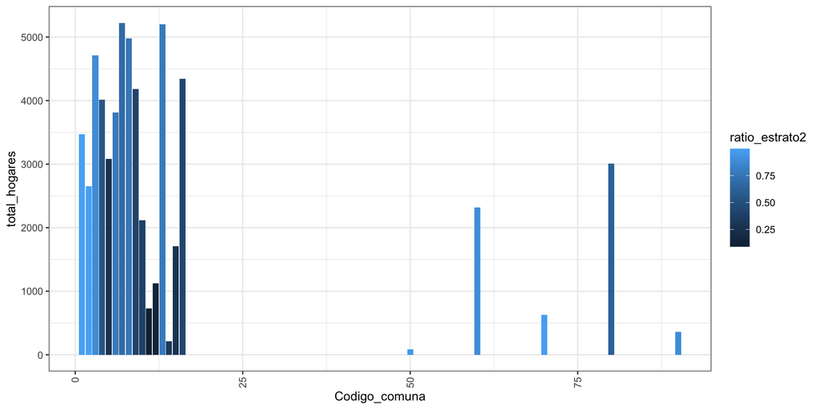

```r
library(doBy)

hogares_barrio_estrato <- read.csv("cantidad_hogares_barrio_estrato_sisben_lll.csv")

hogares_barrio_estrato_2019 <- hogares_barrio_estrato %>%
  filter(Annio==2019) %>%
  mutate(total_hogares = Estrato_0 + Estrato_1 + Estrato_2 + Estrato_3 + Estrato_4 + Estrato_5 + Estrato_6) %>%
  collapse::collap(total_hogares + Estrato_0 + Estrato_1 + Estrato_2 + Estrato_3 + Estrato_4 + Estrato_5 + Estrato_6 ~ Comuna + Codigo_comuna, FUN = "fsum")


hogares_barrio_estrato_2019$ratio_estrato2 = (hogares_barrio_estrato_2019$Estrato_0 + hogares_barrio_estrato_2019$Estrato_1 + hogares_barrio_estrato_2019$Estrato_2)/hogares_barrio_estrato_2019$total_hogares

hogares_barrio_estrato_2019 <- hogares_barrio_estrato_2019 %>%
  mutate(ratio_estrato2_v2 = (Estrato_0 + Estrato_1 + Estrato_2)/total_hogares,
         Codigo_comuna = as.numeric(Codigo_comuna))


hogares_barrio_estrato_2019 %>%
  ggplot() +
  geom_bar(aes(x = Codigo_comuna, y = total_hogares, fill = ratio_estrato2), stat = "identity") +
  theme_bw() +
  theme(axis.text.x = element_text(angle = 90, vjust = 0.5, hjust=1))
```

2. Number of Juntas de Acción Comunal

```r
jac_fichas <- read.csv("fichas_diagnosticas_juntas_de_accion_comunal.csv")

jac_fichas$dignatarios <- as.numeric(jac_fichas$DIGNATARIOS.ACTIVOS)

jac_fichas_collapsed <- jac_fichas %>%
  collapse::collap(dignatarios ~ COMUNA, FUN = "fsum") %>%
  rename(Codigo_comuna = COMUNA)

data1 <- jac_fichas_collapsed %>%
  inner_join(hogares_barrio_estrato_2019, by = "Codigo_comuna")
```

3. Is there a correlation? Is it robust? Is it extrapolable to other contexts?

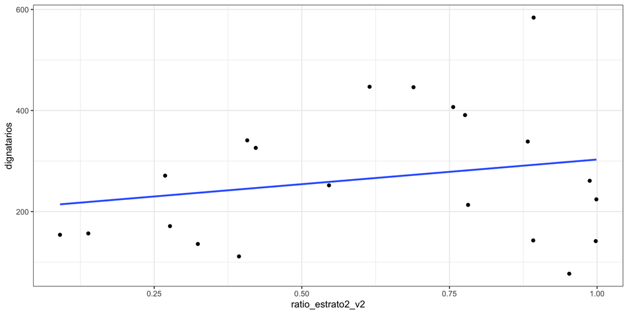

```r
data1 %>%
  ggplot(aes(x = ratio_estrato2_v2, y = dignatarios)) +
  geom_jitter() +
  geom_smooth(method = "lm", se = F) +
  theme_bw()
```

**Stats**

How dare we speak of the laws of chance?

Is not chance the antithesis of all law?

*- Bertrand Russell*

## The agenda for this second half

1. The central limit theorem and the p-value
2. T-test and chi2: relationships between two variables (incl. at least one cat)
3. Covariance and correlation
4. Regression, at last

## Our framework

- Our approach is positivist
- Our tool is comparison
- Our faith rests on the existence of counterfactuals
- Our goal will be to estimate the difference between the counterfactual (non-existent but expected, **or the closest thing to it**) and reality (observed)

**The central limit theorem and the p-value**

## Population and sample

- **Population**: every case of possible relevance. If we study people with the right to vote in Spain, we would be talking about all the inhabitants of the country who make up the electoral roll
- **Sample**: a subset of the population that we are going to analyze. The vast majority of studies in the social sciences work with samples

What type of sample? Random samples where every citizen would have the same probability of being included in

Fundamental: **we are not interested in the sample per se, we use it to learn about the population**

**Statistical inference**: using what we know from a *sample* to infer something *likely* or *probable* about the population

- To do this, we need to consider how **uncertain** our *estimate* is, and assume that the sample is representative of the population, so that we can apply the CLT [normal distribution]

## Mean, variance, SD and SE

**Mean (average)**

$\bar{x} = \frac{\sum_{i=1}^{n} x_i}{n}$

The sum of the values of all observations divided by the number of observations

**Variance and standard deviation (SD)**

$Var(x) = \frac{\sum (x_i-\bar{x})^2}{n-1}$

$SD(x) = \sqrt{Var(x)}$

These measure how spread out the observations are around the mean, on average, after accounting for negative values. The SD is expressed in the same units as the original variable (the variance is not) because first squares and the takes the square root

**Standard error (SE)**

$SE = \frac{SD(x)}{\sqrt{n}}$

Measures the precision of an estimator (such as the sample mean) as an approximation to the population value. Unlike the SD, it depends (more) on sample size. ONLY WITH RANDOM SAMPLES

## The ABCs of random sampling

- Step 1
- Step 2
- Step 3
- Step 4
- Step 5
- Step 6
- Step 7
- Step 8

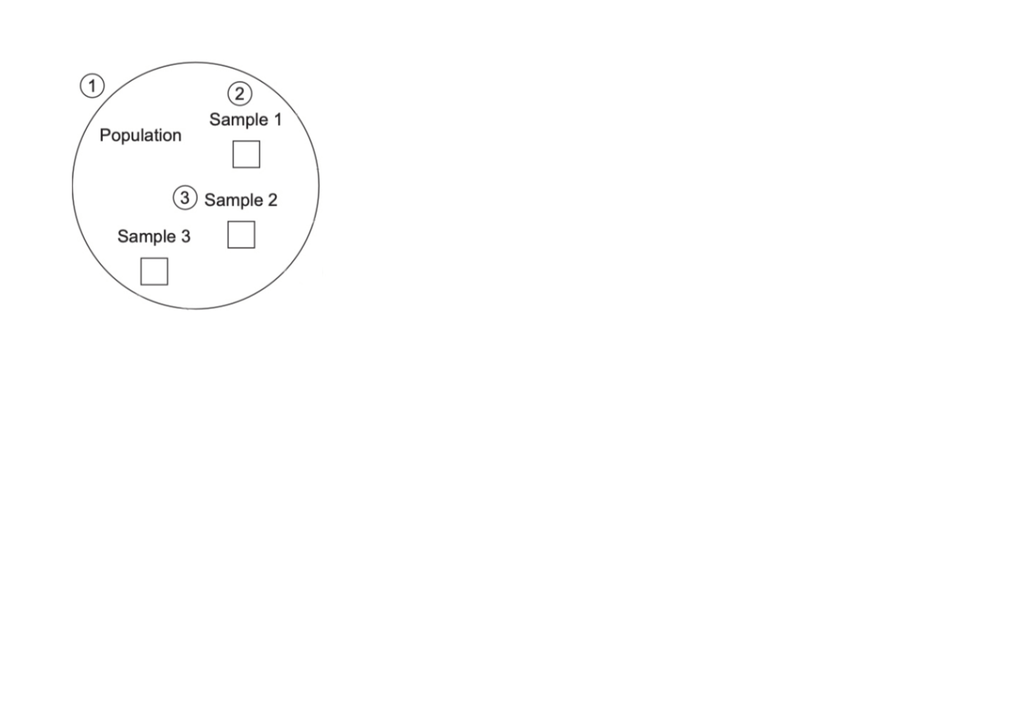

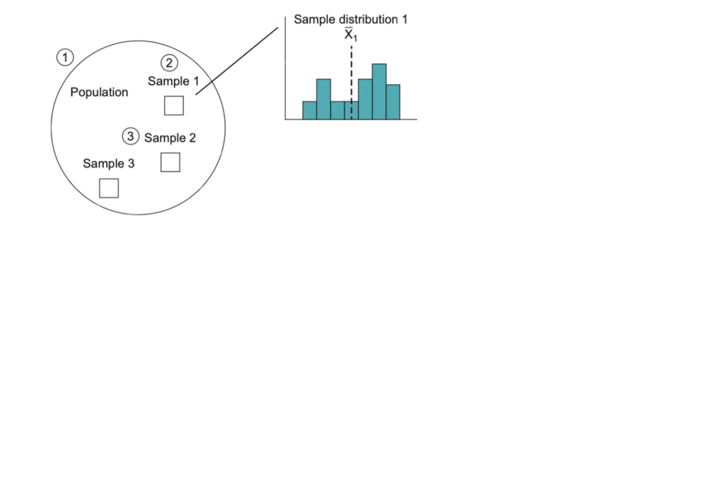

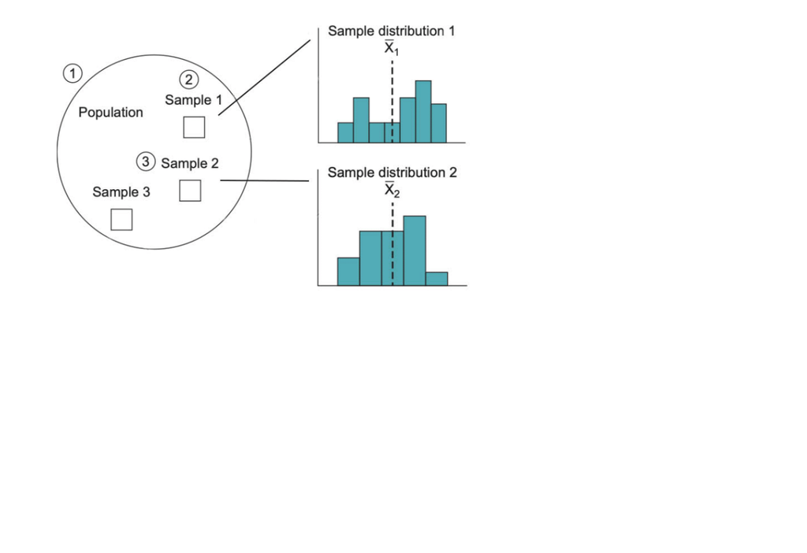

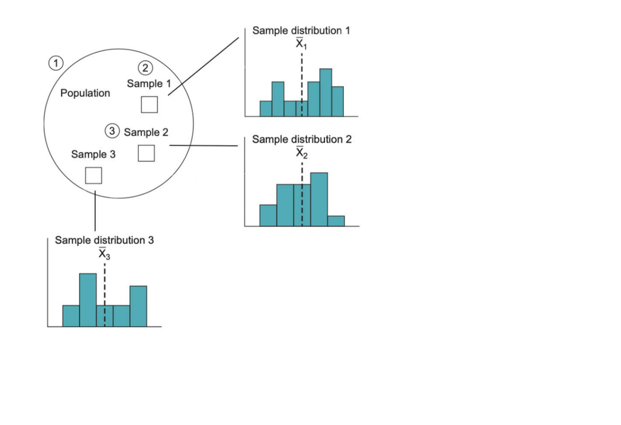

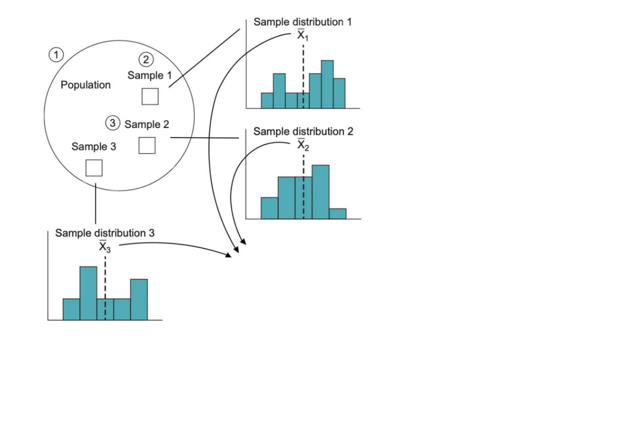

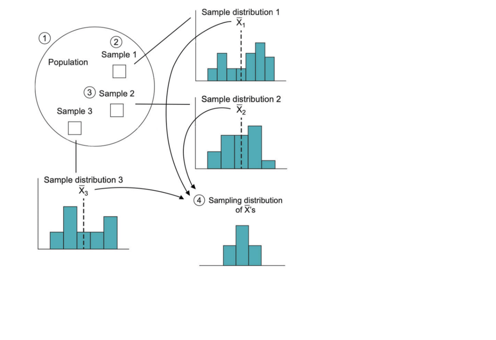

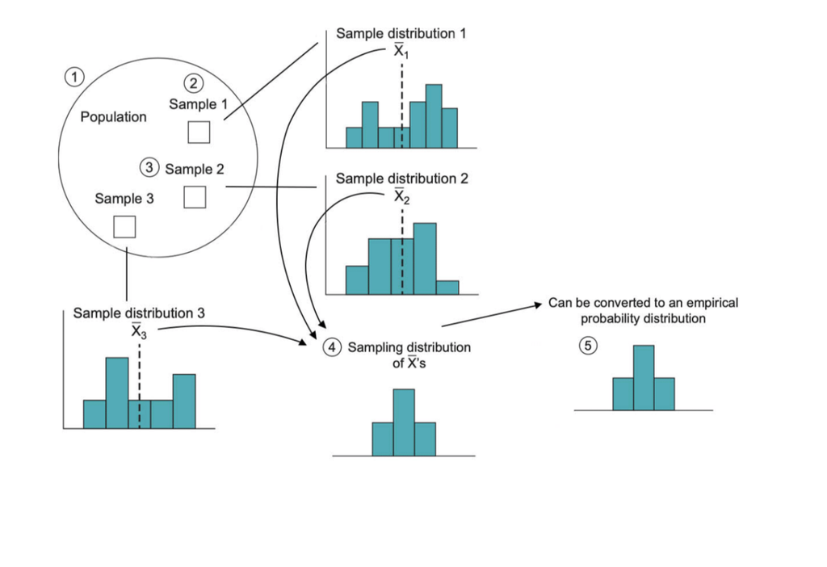

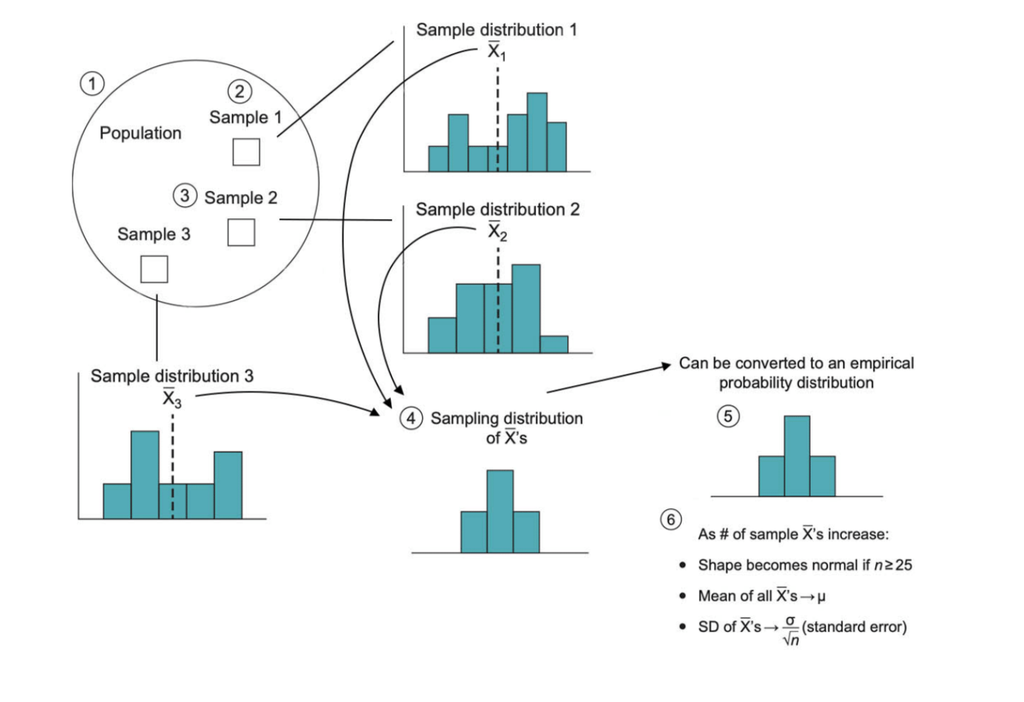

## What is a normal distribution?

Observations cluster together in the shape of a bell

1. They are distributed symmetrically around the mean
2. The mean, the median and the mode are equal

```r
set.seed(1)
norm <- rnorm(1000, mean = 0, sd = 1)

data.frame(norm) %>%
  summary(norm)
```

```
      norm
 Min.   :-3.00805
 1st Qu.:-0.69737
 Median :-0.03532
 Mean   :-0.01165
 3rd Qu.: 0.68843
 Max.   : 3.81028
```

3. 68% of observations are found within 1 SD or less of the mean
4. Within 2 (1.96) SD of the mean we will find 95% of observations

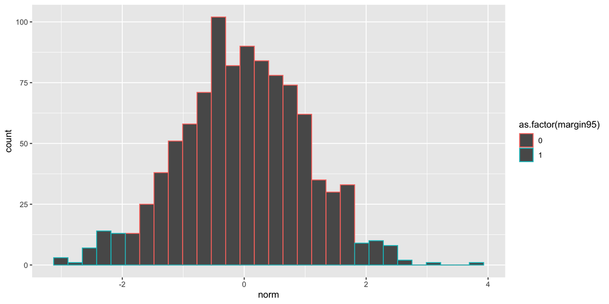

```r
data.frame(norm) %>%
  mutate(margin95 = ifelse((norm < (-1.95)) | (norm > (1.95)), 1, 0)) %>%
  ggplot(aes(x = norm, color = as.factor(margin95))) +
  geom_histogram(position = "identity")
```

## The concept of *statistically significant*

“This effect is statistically significant at the 95%.”

The value obtained is *so atypical* that the probability that the *null hypothesis* (usually, that there is no relationship between two variables, or that both groups are equal) is true is *lower than 5%*

**Why?**

Because, taking into account the information and the uncertainty present in our sample, we can build an interval within which the population mean will fall

## Why do we want this?

Main news from last week:

[figure not shown]

[figure not shown]

[figure not shown]

## A poll is a single sample/realization

We start from the [open microdata of the 40dB barometer from October 2026](https://elpais.com/espana/2026-10-05/consulte-todos-los-datos-internos-de-la-encuesta-de-el-pais-cuestionarios-cruces-y-respuestas-individuales.html). We clean up direct voting intention (`p3`), weight it (`ponde`) and estimate the PP’s vote share with its confidence interval.

```r
library(tidyverse)
library(haven)

datos <- read_dta("03_Datos_octubre_2026.dta", encoding = "latin1")

# Codes 1 to 18 of p3 are parties. We exclude blank, null,
# would-not-vote, don't-know and no-answer (codes 19 to 23)
limpio <- datos |>
  filter(p3 %in% 1:18) |>
  transmute(pp = as.integer(p3 == 2), ponde)

n     <- nrow(limpio)
n_ef  <- sum(limpio$ponde)^2 / sum(limpio$ponde^2)   # effective sample size
p_hat <- weighted.mean(limpio$pp, limpio$ponde)
se    <- sqrt(p_hat * (1 - p_hat) / n_ef)

tibble(n, n_ef, p_hat, se,
       inferior = p_hat - 1.96 * se,
       superior = p_hat + 1.96 * se)
```

```
# A tibble: 1 × 6
      n  n_ef p_hat     se inferior superior
  <int> <dbl> <dbl>  <dbl>    <dbl>    <dbl>
1  1573 1434. 0.249 0.0114    0.227    0.272
```

**Question.** What would have happened in another identical poll, with other randomly interviewed people?

## Ten thousand possible polls, a single bell

Suppose the population value is exactly the one we estimated, and we repeat the poll 10,000 times. The CLT says $\hat{p}$ is distributed approximately as

$$\hat{p} \;\approx\; N \left(p,\; \sqrt{\tfrac{p(1-p)}{n_{ef}}}\right)$$

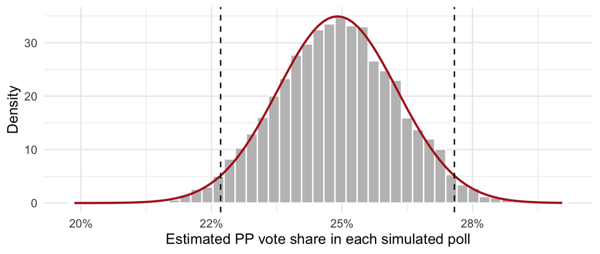

```r
set.seed(2026)
B <- 10000

sondeos <- tibble(p_sim = rbinom(B, size = round(n_ef), prob = p_hat) / round(n_ef))

ggplot(sondeos, aes(p_sim)) +
  geom_histogram(aes(y = after_stat(density)), bins = 45,
                 fill = "grey75", colour = "white") +
  stat_function(fun = dnorm, args = list(mean = p_hat, sd = se),
                colour = "firebrick", linewidth = 1) +
  geom_vline(xintercept = p_hat + c(-1.96, 1.96) * se, linetype = "dashed") +
  scale_x_continuous(labels = scales::label_percent(accuracy = 1)) +
  labs(x = "Estimated PP vote share in each simulated poll", y = "Density") +
  theme_minimal(base_size = 14)
```

```r
c(media_sim = mean(sondeos$p_sim), sd_sim = sd(sondeos$p_sim), se_teorico = se)
```

```
 media_sim     sd_sim se_teorico
0.24908187 0.01148462 0.01142272
```

The dashed lines leave out 5% of the polls. The margin of error describes that sampling distribution, not any single poll.

## Limits and conditions of the CLT

The central limit theorem **only** applies to random samples

- Non-random samples are less helpful for learning about the population; for example, a survey among a newspaper’s subscribers or a mailing list has nothing to do with a random survey

The SD and SE formulas underline the importance of sample size

- How large should my sample be? At least 30 observations. *The trade-off between cost and precision*, usually *solved* with power analysis

The truth: We will work with non-random samples most times and, still, these tools will be useful to us; this is the best we have to cope with uncertainty

**T-test and chi2**

## 2 variables: testing hypotheses

The type of test to implement depends on the type of variables, continuous versus categorical or binary

Examples:

1. Do men vote for far-right parties more than women? (categ. vs. cont./bin.)
2. Do we become more right-wing as we age? (cont. vs. cont.)

|  | **Categorical** | **Continuous** |
| --- | --- | --- |
| **Continuous** | Difference of means (t-test) | Correlation/Regression |
| **Categorical** | Cross-tab analysis ($Chi^2$) | Logit/probit/Regression |

These tools share the use of the p-value

## The p-value

1. The logic of the comparison

Definition:

1. The probability of obtaining a statistic at least as extreme as the one observed if the null hypothesis were true
2. The probability that the relationship found is the product of chance or of our sample’s bias, and therefore not applicable to the population
- Larger difference -> greater confidence that this relationship can be extrapolated from our sample to the population
- Larger n -> greater confidence that this relationship can be extrapolated from our sample to the population
2. It comes from the t statistic (chi2 is “similar”): effect / error, i.e. how many standard errors we need to discount our estimate down to 0/null
3. A value between 0 and 1. The lower the p-value, the more certain the relationship between X and Y is in the sample
4. What is the p-value not?
- It is not reversible. p=0.001 does not mean there is a 0.999 probability that something systematic is happening
- Just like the SD or the SE, the p-value is a function of sample size. A larger sample informs us about the confidence of that relationship in our sample, not about whether the relationship is stronger in the population
- It only works with random samples and does **(NOT)** tell us anything about causality

## Chi2: the sachisfaction

As in life, Chi2 is about comparing what is expected with what is observed

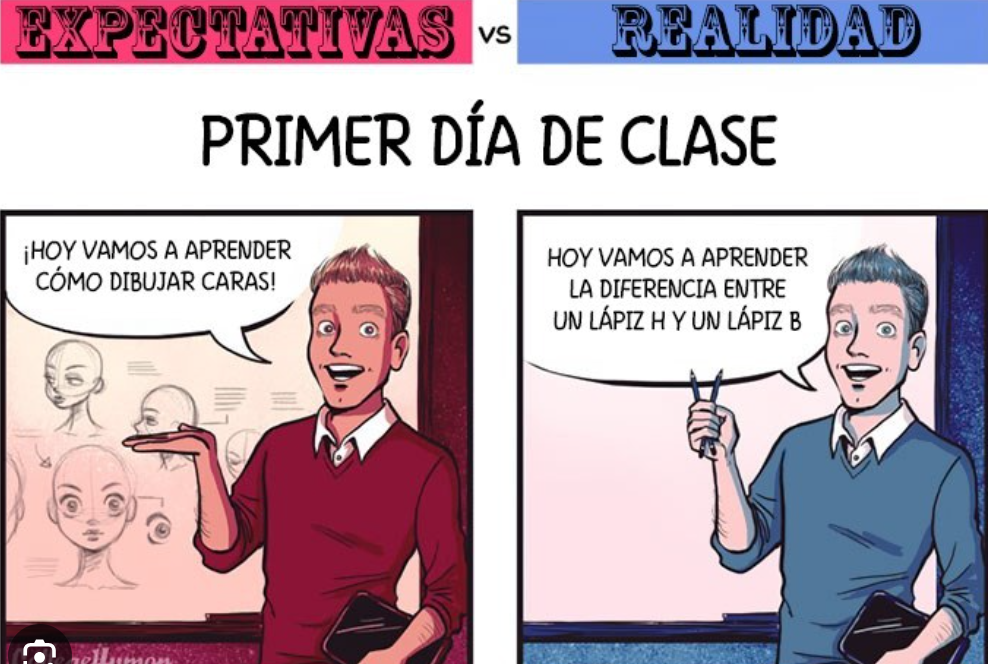

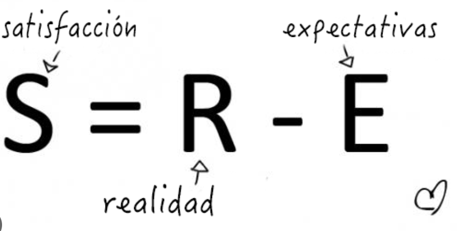

**Chi2**: whether there is a relationship between variables is determined by the difference between the expected distribution [the counterfactual where no such relationship exists] of frequencies and the one we observe

## Chi2, example. The Trump-Clinton gender gap

What data do we need?

- Trump got 48% of the counted vote [not the districts, you know]. Clinton got 52%
- **Null hypothesis**: assuming there is no relationship, the distribution would be the same across genders
- **Alternative hypothesis**: there is a gender that voted more, on average, for Trump than the other

**Expected distribution (no relationship, null hypothesis) vs. Observed distribution**

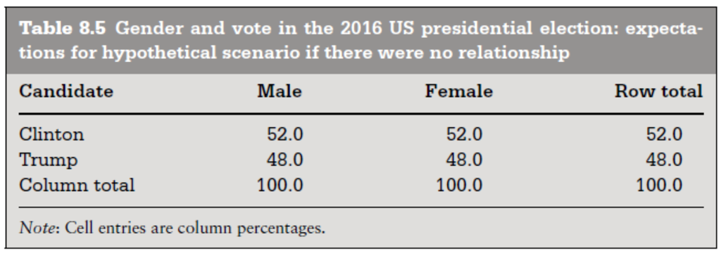

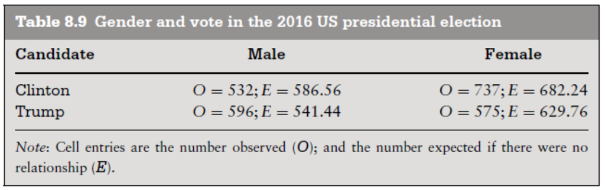

## Calculating and interpreting chi2

$X^2 = \sum{\frac{(O_i-E_i)^2}{E_i}}$

```r
(((532-586.56)^2)/586.56) + (((736-682.24)^2)/682.24) +
  (((596-541.44)^2)/(541.44)) + (((575-629.76)^2)/629.76)
```

```
[1] 19.57076
```

$X^2 = 19.57$. Degrees of freedom (df) = (N columns - 1) x (N rows - 1) = 1

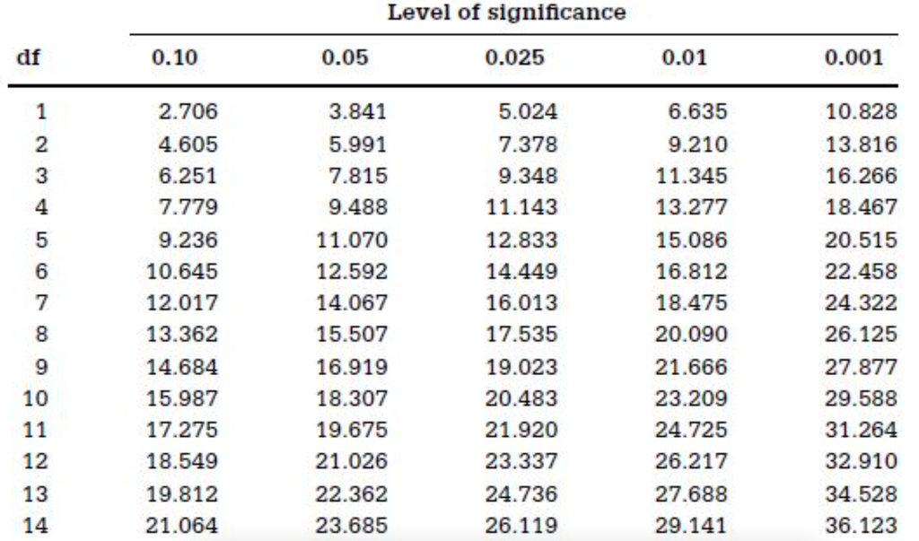

Chi2 = 19.57 > 3.8, so the p-value of this relationship is **below** the established threshold. There is a significant difference between the observed and expected proportion of women voting for Trump

## T-test, the story of “Student”

Mr. William Sealy Gosset, alias *Student*. He was studying chemistry at Oxford, and was recruited by the Guinness brewery into its quality-control department

How do we detect whether the amount of a component X differs from what is *normal*?

H1: M1 - M2 = 0 [both groups are equal, the expected counterfactual]

H2: M1 - M2 ≠ 0 [reality]

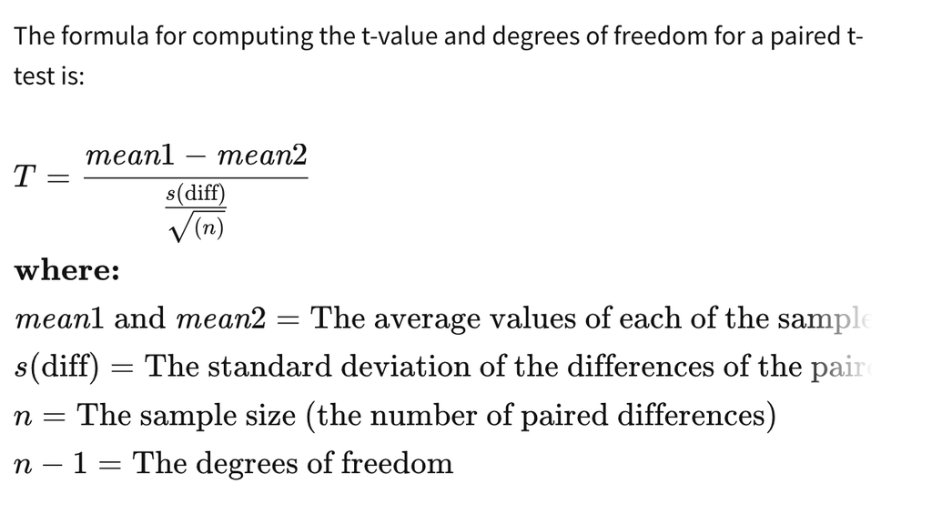

We want to obtain a p-value (based on a t-statistic) regarding the difference in the levels of a continuous variable between the categories of a categorical variable

## T-test: a tomato example

- Carlos has 2 (separate) tomato fields. He put fertilizer on one and not on the other
- He wants to know if it works, i.e. whether the dosed plants are taller
- He takes a random sample of the tomato plants in each of the fields

|  | Field Nope | Field Dope |
| --- | --- | --- |
| Mean | 1.3 | 1.6 |
| Std deviation | 0.5 | 0.3 |
| N | 22 | 24 |

$T = \frac{x_a - x_b}{\sqrt{\frac{(s_a)^2}{n_a} + \frac{(s_b)^2}{n_b}}}$

```r
(1.3 - 1.6) / sqrt(((0.5^2)/22) + ((0.3^2)/24))
```

```
[1] -2.440264
```

We need to go back to the T distribution to find the equivalent in terms of a p-value

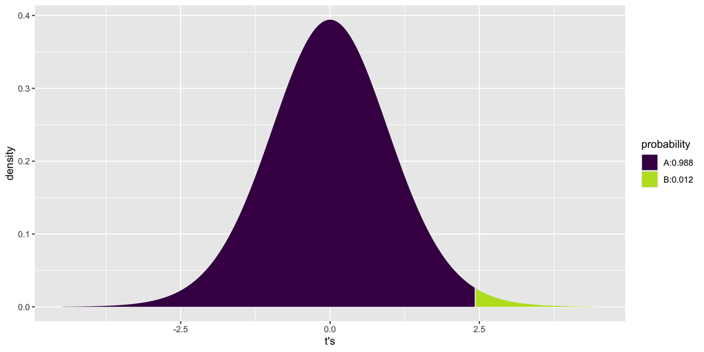

```r
xpt <- xpt(q = 2.44, df = 21, xlab = "t's")
```

## T-test: an example with the left-wing parties

- Let’s go back to the 40dB data
- Question: *Do those who would vote for ERC or Bildu differ in their housing policy preferences* (`p22`) *from those who would vote for Sumar or Podemos?* **Was Rufi right about her coalition proposal?**

```r
library(broom)

izq <- datos |>
  zap_labels() |>
  filter(p3 %in% c(4, 5, 7, 10)) |>
  mutate(
    bloque = if_else(p3 %in% c(7, 10), "ERC y Bildu", "Sumar y Podemos"),
    # 5 is "Don't know". We reverse the scale so that higher means more agreement (1 to 4)
    across(starts_with("p22_"), ~ if_else(.x == 5, NA_real_, 5 - .x))
  )

# One specific item (p22_3, tax advantages for small landlords renting at affordable prices)
t.test(p22_3 ~ bloque, data = izq)
```

```
    Welch Two Sample t-test

data:  p22_3 by bloque
t = 3.6095, df = 153.92, p-value = 0.0004145
alternative hypothesis: true difference in means between group ERC y Bildu and group Sumar y Podemos is not equal to 0
95 percent confidence interval:
 0.1853865 0.6336611
sample estimates:
    mean in group ERC y Bildu mean in group Sumar y Podemos
                     3.566667                      3.157143
```

```r
# All 12 items at once, with Bonferroni correction for multiple comparisons
resultados <- izq |>
  pivot_longer(starts_with("p22_"), names_to = "item", values_to = "acuerdo") |>
  group_by(item) |>
  group_modify(~ tidy(t.test(acuerdo ~ bloque, data = .x))) |>
  ungroup() |>
  mutate(p_bonferroni = p.adjust(p.value, method = "bonferroni"))

resultados |> select(item, estimate, statistic, p.value, p_bonferroni)
```

```
# A tibble: 12 × 5
   item   estimate statistic  p.value p_bonferroni
   <chr>     <dbl>     <dbl>    <dbl>        <dbl>
 1 p22_1   -0.0560    -0.600 0.549         1
 2 p22_10   0.0725     0.543 0.588         1
 3 p22_11  -0.0693    -0.729 0.467         1
 4 p22_12   0.0134     0.115 0.909         1
 5 p22_2    0.0229     0.174 0.862         1
 6 p22_3    0.410      3.61  0.000414      0.00497
 7 p22_4    0.156      1.37  0.174         1
 8 p22_5   -0.0685    -0.451 0.653         1
 9 p22_6   -0.159     -1.22  0.225         1
10 p22_7    0.0445     0.449 0.654         1
11 p22_8   -0.165     -1.36  0.177         1
12 p22_9   -0.156     -0.967 0.336         1
```

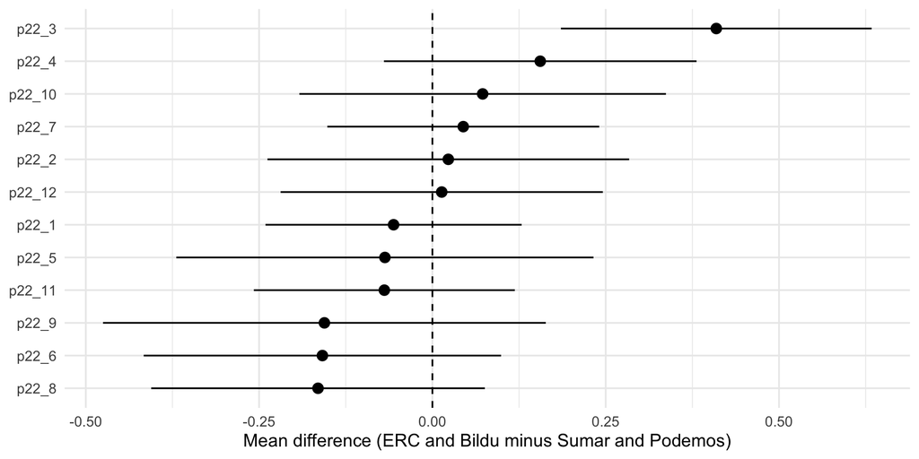

```r
ggplot(resultados, aes(x = estimate, y = reorder(item, estimate))) +
  geom_pointrange(aes(xmin = conf.low, xmax = conf.high)) +
  geom_vline(xintercept = 0, linetype = "dashed") +
  labs(x = "Mean difference (ERC and Bildu minus Sumar and Podemos)", y = NULL) +
  theme_minimal(base_size = 14)
```

## Another example, Don Green

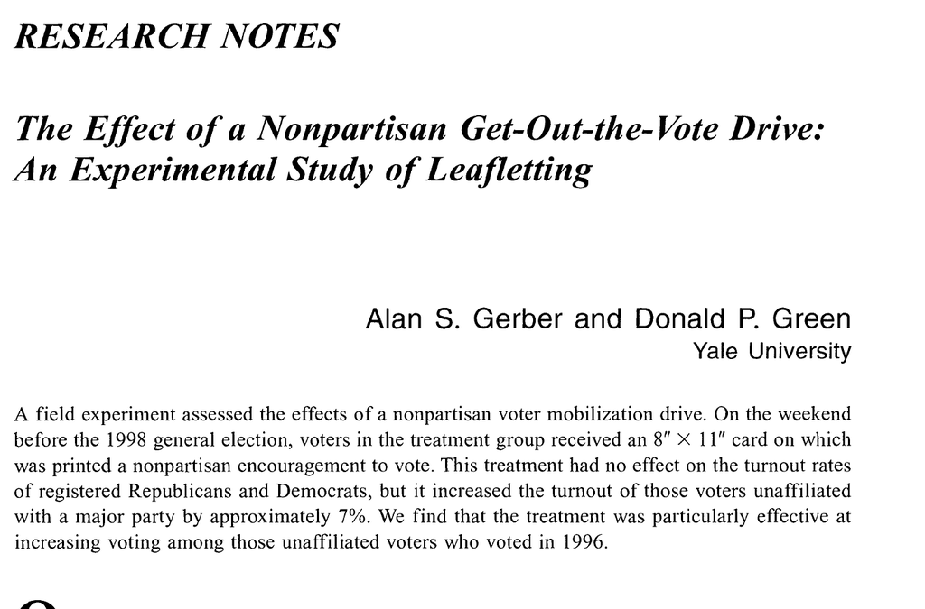

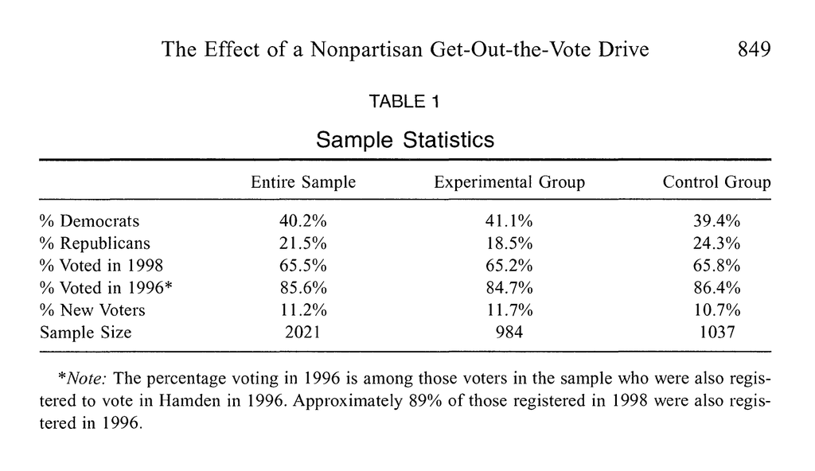

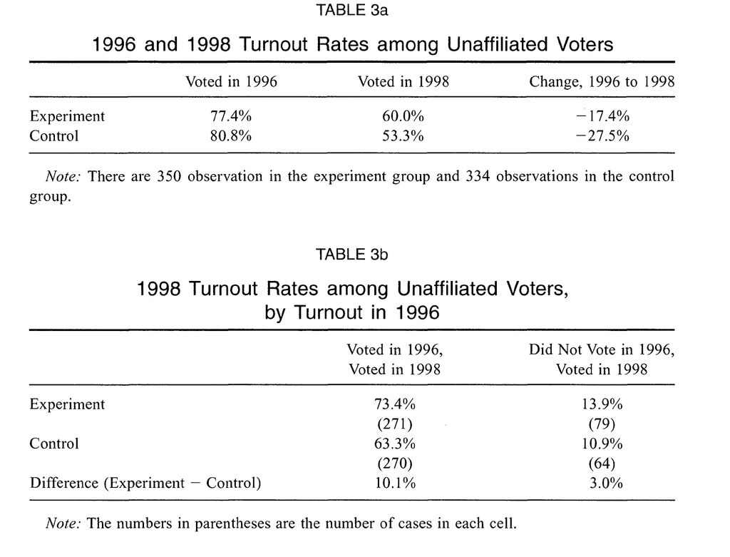

## Change over time: treatment versus control

**Question.** Did turnout drop less between 1996 and 1998 in the experimental group than in the control group?

$t = \dfrac{(\hat{p}_{E,98}-\hat{p}_{E,96}) - (\hat{p}_{C,98}-\hat{p}_{C,96})}{\sqrt{SE_E^2 + SE_C^2}}$

with $SE_g^2 = \dfrac{\hat{p}_{g,96}(1-\hat{p}_{g,96})}{n_g} + \dfrac{\hat{p}_{g,98}(1-\hat{p}_{g,98})}{n_g}$

```r
n_e <- 350; n_c <- 334
e96 <- .774; e98 <- .600
c96 <- .808; c98 <- .533

# Change in each group and its standard error
cambio_e <- e98 - e96                                   # -0.174
cambio_c <- c98 - c96                                   # -0.275
se_e <- sqrt(e96*(1-e96)/n_e + e98*(1-e98)/n_e)
se_c <- sqrt(c96*(1-c96)/n_c + c98*(1-c98)/n_c)

# Difference of changes
dif <- cambio_e - cambio_c                              # 0.101
t_dif <- dif / sqrt(se_e^2 + se_c^2)
p_dif <- 2 * pt(-abs(t_dif), df = n_e + n_c - 2)

c(dif = dif, t = t_dif, p = p_dif)
```

```
       dif          t          p
0.10100000 2.06371056 0.03942294
```

**Result.** The experimental group drops 10.1 points less than the control group, with $t = 2{.}06$ and $p \approx 0{.}039$. We reject that the evolution is the same in both groups at the 0.05 level

**Caveat.** We treat 1996 and 1998 as independent because the table does not give the correlation between the two years for the same people. Since that correlation is positive, the true standard error is smaller, and the result, if anything, would be stronger

### Extra ball: main assumption of Green and Gerber (2000)

Would you interpret this effect as causal? What is the main assumption? How would you test/document/verify it?

. . .

Comparability before treatment:

```r
se_96 <- sqrt(e96*(1-e96)/n_e + c96*(1-c96)/n_c)
t_96  <- (e96 - c96) / se_96
p_96  <- 2 * pt(-abs(t_96), df = n_e + n_c - 2)

c(dif = e96 - c96, t = t_96, p = p_96)
```

```
       dif          t          p
-0.0340000 -1.0949175  0.2739393
```

| Comparison | Difference | t | p |
| --- | --- | --- | --- |
| 1996 turnout (design validity) | −0.034 | −1.09 | 0.27 |
| 1998 turnout | 0.067 | 1.77 | 0.077 |
| **Change from 1996 to 1998** | **0.101** | **2.06** | **0.039** |

With $p = 0{.}27$ there is no evidence of prior differences, which supports the idea that the groups were comparable. And comparing the change over time is more informative than comparing 1998 alone, because it nets out each group’s starting level

**Covariance and correlation**

## Summarizing the relationship between two variables

Education and ideology. *How would you summarize the relationship?*

1. **Compare the means** of one variable (y) across the values of the other (x)
2. Show the **covariance/correlation**
3. Show the **regression coefficients**
4. Add control variables (against omitted-variable bias)
5. Design an experiment

## Comparing means

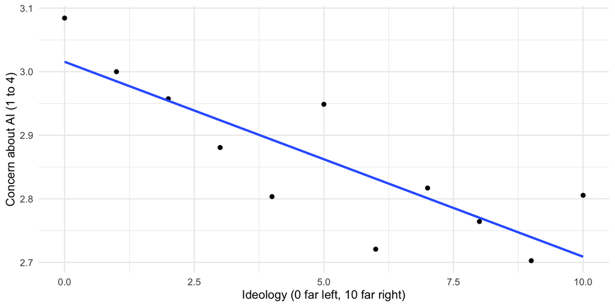

```r
datos |>
  zap_labels() |>
  select(ideologia = p7, ia = p8_8) |>
  mutate(
    ideologia = if_else(ideologia == 99, NA_real_, ideologia),  # 99 is Don't know
    # 5 is Don't know. We reverse the scale so that higher means more concern (1 to 4)
    ia = if_else(ia == 5, NA_real_, 5 - ia)
  ) |>
  drop_na() |>
  group_by(ideologia) |>
  summarise(ia_mean = mean(ia), .groups = "drop") |>
  ggplot(aes(x = ideologia, y = ia_mean)) +
  geom_point() +
  geom_smooth(method = "lm", se = F) +
  labs(x = "Ideology (0 far left, 10 far right)", y = "Concern about AI (1 to 4)") +
  theme_minimal(base_size = 14)
```

## Comparing means -> comparing variances

- Let’s switch examples: now we’ll talk about the association between education and concern about AI
- We take a step back and go back to the variance of each variable

Variance: a measure of the **dispersion** of a single variable

$Var(x)=\frac{\sum{(x_i-\bar{x})^2}}{n-1}$

## An example with 4 people

**Made-up** data on education (years of schooling) and concern about AI (1 to 4, higher is more concern)

```r
library(tidyverse)

ejemplo <- tibble(
  persona = c("A", "B", "C", "D"),
  educacion = c(8, 10, 14, 16),
  ia = c(4, 3, 3, 2)
)

ejemplo
```

```
# A tibble: 4 × 3
  persona educacion    ia
  <chr>       <dbl> <dbl>
1 A               8     4
2 B              10     3
3 C              14     3
4 D              16     2
```

**First, let’s look at the data**

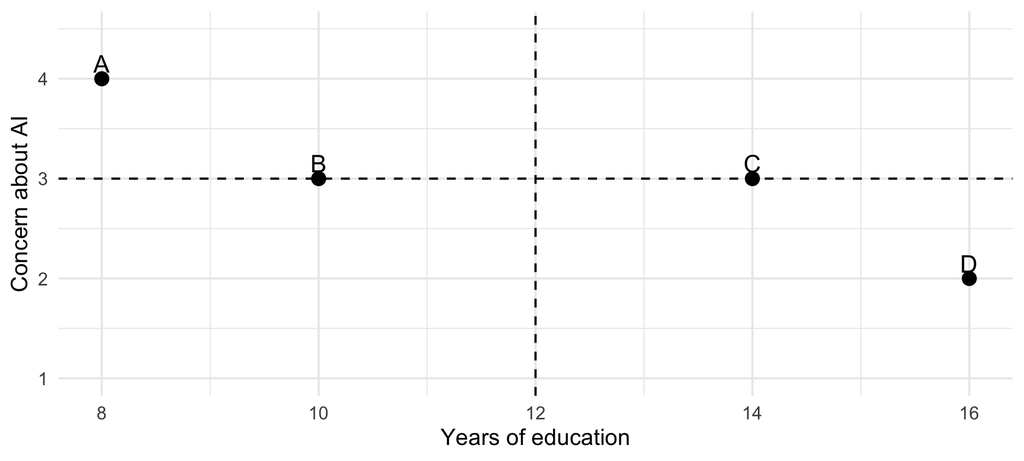

```r
ggplot(ejemplo, aes(educacion, ia, label = persona)) +
  geom_vline(xintercept = mean(ejemplo$educacion), linetype = "dashed") +
  geom_hline(yintercept = mean(ejemplo$ia), linetype = "dashed") +
  geom_point(size = 4) +
  geom_text(nudge_y = 0.15, size = 6) +
  scale_y_continuous(limits = c(1, 4.5)) +
  labs(x = "Years of education", y = "Concern about AI") +
  theme_minimal(base_size = 16)
```

***Second, deviations from the mean** aka. variances

```r
ejemplo <- ejemplo |>
  mutate(
    dx = educacion - mean(educacion),
    dy = ia - mean(ia),
    dx2 = dx^2,
    dy2 = dy^2,
    dxdy = dx * dy
  )

ejemplo
```

```
# A tibble: 4 × 8
  persona educacion    ia    dx    dy   dx2   dy2  dxdy
  <chr>       <dbl> <dbl> <dbl> <dbl> <dbl> <dbl> <dbl>
1 A               8     4    -4     1    16     1    -4
2 B              10     3    -2     0     4     0     0
3 C              14     3     2     0     4     0     0
4 D              16     2     4    -1    16     1    -4
```

- `dx2` and `dy2` feed the **variance**
- `dxdy` feeds the **covariance**. It is positive if both points are on the same side of their means, and negative if they are on opposite sides

**Third, variance and covariance by hand**

```r
n <- nrow(ejemplo)

var_x  <- sum(ejemplo$dx2) / (n - 1)    # 40 / 3
var_y  <- sum(ejemplo$dy2) / (n - 1)    # 2 / 3
cov_xy <- sum(ejemplo$dxdy) / (n - 1)   # -8 / 3

c(var_x = var_x, var_y = var_y, cov_xy = cov_xy)
```

```
     var_x      var_y     cov_xy
13.3333333  0.6666667 -2.6666667
```

$Cov(education, AI) = -2{.}67$ indicates that more education is associated with less concern about AI. But that −2.67 does not tell us whether the association is strong or weak (in months it would be −32)

**What it tells us.** The *direction* of the linear association between two variables

- $Cov > 0$ when one variable is above its mean, the other tends to be too
- $Cov < 0$ when one is above its mean, the other tends to be below
- $Cov \approx 0$ there is no linear association

**How to interpret it:** We stick to the **sign**, not the magnitude (it depends on the units, so it is not comparable across pairs of variables)